# HW1 - Linear Model and ANOVA

Keanu Rochette

2025-01-21

## Load Libraries

```r
# Data manipulation and visualization
library(tidyverse)
library(here)
library(janitor)
library(ghibli)
library(gt)

# Data analysis/statistics
library(car) #ANOVA
library(ggeffects)
library(effects) #dependency for ggeffects
library(ggResidpanel) #residual panel
library(GGally)
```

## Load Data

```r
bird <- read_csv(here("HW1", "data", "foraging.height.csv"))
```

## Data clean-up

```r
bird <- clean_names(bird) # transforms column names in R friendly format
bird <- bird %>%
  select (-x1) %>%
  mutate(date = mdy(date), # correct date format
         kipuka = factor(kipuka), # make kipuka name a factor
         rat_removal = factor(rat_removal, levels= c("untreated", "treated"))) %>% # make treatment status a factor
  filter(species != "OMAO", species != "HAEL") # species not included in the HW
```

## Question 1

- How many observations are there of each bird species in each experimental treatment?

### Summary Table

The number of observations is given in the data table below. We can note that APAP species has overall a greater number of observations compared to other bird species.

```r
bird %>% group_by(species, rat_removal) %>%
  summarize(n = n()) %>% #gives the number of data point in designated categories
  ungroup() %>%
  gt() %>%
  tab_header(title = "Data Summary of Birds Species by Treatment") %>%
  cols_label(species = "Species",
             rat_removal = "Rat Removal",
             n = "Number of data point (n)")
```

Data Summary of Birds Species by Treatment

| Species | Rat Removal | Number of data point (n) |
| --- | --- | --- |
| APAP | untreated | 188 |
| APAP | treated | 131 |
| HAAM | untreated | 42 |
| HAAM | treated | 47 |
| IIWI | untreated | 43 |
| IIWI | treated | 30 |
| JAWE | untreated | 9 |
| JAWE | treated | 16 |

### Plots

Make a boxplot or violinplot to show the distribution of foraging heights of each bird species in each experimental treatment. What have you learned so far?

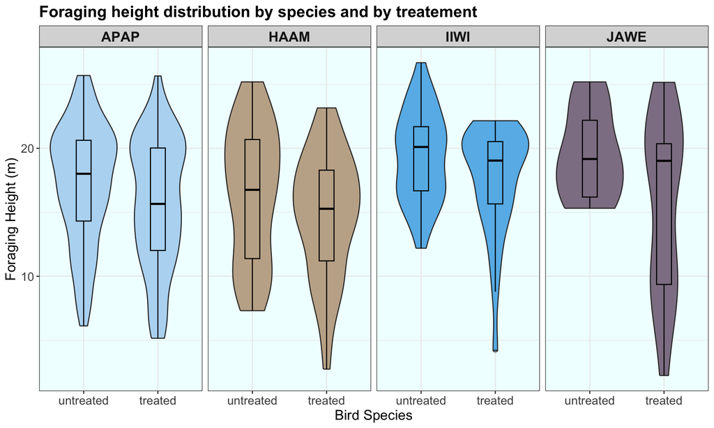

```r
ggplot(bird, aes(x= rat_removal, y = foraging_ht_m)) +
  geom_violin(aes(fill = species))+
  geom_boxplot(aes(fill = species), width=0.2, color="black", alpha=0.2)+
  facet_grid(.~species)+

  # Making the graph pretty
  labs(title = "Foraging height distribution by species and by treatement",
       x = "Bird Species", y = "Foraging Height (m)")+
  theme_bw()+
  theme(plot.title = element_text(size=16, face = "bold"),
        plot.subtitle = element_text(size=15, face = "italic"),
        axis.title = element_text(size = 14),
        axis.text = element_text(size = 12),
        strip.text.x = element_text(size = 14, face = "bold"),
        legend.title = element_text(face = "bold"),
        legend.text = element_text(size = 12),
        panel.background = element_rect(fill = "azure1"),
        legend.position="none") +
  scale_fill_ghibli_d("SpiritedMedium", direction = -1)
```

### Answer

- **General observation**: All bird species in the treatment groups can be observed at lower foraging heights compared to untreated areas.
- **Foraging range**: The effect of the treatment seem to be especially beneficial to IIWI and JAWE because their foraging range has increase more than the other 2 species. HAAM also benefited from rat removal but the effect of the treatment is lesser than IIWI and JAWE. APAP has experienced an increased in foraging range but to a lesser extend than the other species.
- **Median**: Although the overall foraging range has increased for JAWE and IIWI, the median foraging height still remains constant between treated and untreated areas. APAP and HAAM may not have experienced large increase in foraging range, but the median foraging range is lower in treated areas compared to untreated areas. This may indicated that APAP and HAAM and decreasing their foraging height in the absence of rats.

## Question 2

- Make a plot showing the **mean foraging height** of each bird species in each treatment, and include error bars displaying +/- one standard error of the mean.
- What is the meaning of the standard error of the mean? How does this plot differ from the plot in #1?

### Table summary

```r
bird %>% group_by(species, rat_removal) %>%
  summarise(avg_fr_ht = mean(foraging_ht_m,na.rm = T),
            std_err = sd(foraging_ht_m, na.rm=T)/sqrt(length(foraging_ht_m)))
```

```
## # A tibble: 8 × 4
## # Groups:   species [4]
##   species rat_removal avg_fr_ht std_err
##   <chr>   <fct>           <dbl>   <dbl>
## 1 APAP    untreated        17.3   0.336
## 2 APAP    treated          15.7   0.436
## 3 HAAM    untreated        16.5   0.803
## 4 HAAM    treated          14.8   0.697
## 5 IIWI    untreated        19.3   0.534
## 6 IIWI    treated          17.5   0.777
## 7 JAWE    untreated        19.6   1.16
## 8 JAWE    treated          15.6   1.70
```

### Plots

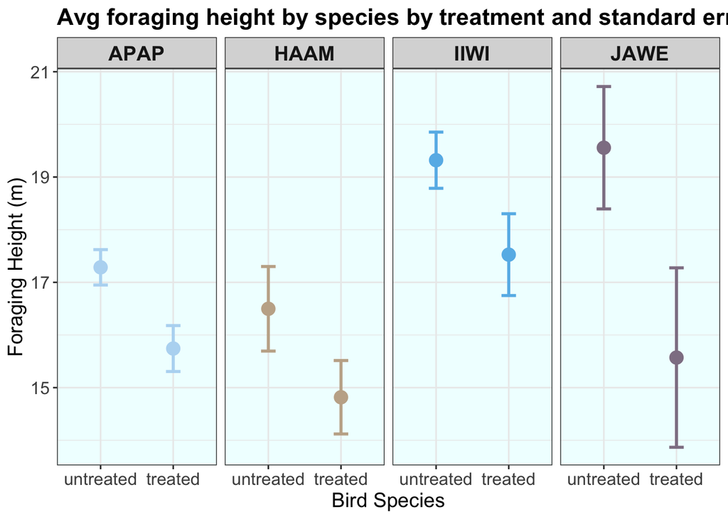

```r
bird %>% group_by(species, rat_removal) %>%
  summarise(avg_fr_ht = mean(foraging_ht_m,na.rm = T),
            std_err = sd(foraging_ht_m, na.rm=T)/sqrt(length(foraging_ht_m))) %>%
  ggplot(aes(x=rat_removal, y= avg_fr_ht, color = species))+
  geom_point(size = 4)+
  geom_errorbar(aes(ymin = avg_fr_ht-std_err, ymax = avg_fr_ht+std_err),
                width = 0.2, linewidth = 1) +
  facet_wrap(.~species, nrow = 1) +

  # Making the graph pretty
  labs(title = "Avg foraging height by species by treatment and standard error",
       x = "Bird Species", y = "Foraging Height (m)")+
  theme_bw()+
  theme(plot.title = element_text(size=16, face = "bold"),
        plot.subtitle = element_text(size=15, face = "italic"),
        axis.title = element_text(size = 14),
        axis.text = element_text(size = 12),
        strip.text.x = element_text(size = 14, face = "bold"),
        legend.title = element_text(face = "bold"),
        legend.text = element_text(size = 12),
        panel.background = element_rect(fill = "azure1"),
        legend.position="none") +
  scale_color_ghibli_d("SpiritedMedium", direction = -1)
```

### Answer

- Standard error of the mean is a measure of how different the mean of a sample would be compared to the mean of the population from which the sample was taken from. It is calculated using the formula: stderr = std.dev() / sqrt(n)
- Violin and box plots show the distribution of a data set, displaying summary statistics such as the range (max and min), the median, the quantiles (25% and 75%) as well as potential outliers.
- The plot below shows the mean and the standard error. The mean is a measure of central location, i.e., on average at what foraging height are bird species feeding in treated and untreated areas.
- We can see that the average graph show a clearer trend than the box plots. It looks like on average, the removal of rats in a kipuka allows bird species to forage at a lower height than in untreated areas.
- We can also see that the error bars are not the same length in all categories. It looks like categories with more data point experience lower error bars compared to categories with fewer data points.

## Question 3

- Fit a linear model that tests whether the bird species differ in foraging height, whether the rat removal treatment affects foraging height, and whether the effect of the rat removal differs between the bird species.
- Make plots to assess the distribution of the residuals. Report F-tests for the terms of the model. Create an effects plot displaying the fitted effects. How do you interpret the results? What are the magnitudes of the effects?

### Linear model including interaction term

This model used the foraging height as a response (depend) variable. We will be using the species, the treatment (rat removal) and the interaction between species and treatment to see how those affect the foraging height.

```r
forg_height_lm <- lm(foraging_ht_m ~ species + rat_removal + species:rat_removal,
                     data = bird)
# also, forg_height_lm <- lm(foraging_ht_m ~ species*rat_removal, data = bird)

summary(forg_height_lm)
```

```
##
## Call:
## lm(formula = foraging_ht_m ~ species + rat_removal + species:rat_removal,
##     data = bird)
##
## Residuals:
##      Min       1Q   Median       3Q      Max
## -13.3712  -3.2434   0.4048   3.5558   9.9124
##
## Coefficients:
##                                Estimate Std. Error t value Pr(>|t|)
## (Intercept)                     17.2852     0.3460  49.956  < 2e-16 ***
## speciesHAAM                     -0.7875     0.8097  -0.973  0.33121
## speciesIIWI                      2.0347     0.8020   2.537  0.01148 *
## speciesJAWE                      2.2715     1.6188   1.403  0.16118
## rat_removaltreated              -1.5426     0.5399  -2.857  0.00446 **
## speciesHAAM:rat_removaltreated  -0.1377     1.1429  -0.120  0.90414
## speciesIIWI:rat_removaltreated  -0.2512     1.2511  -0.201  0.84097
## speciesJAWE:rat_removaltreated  -2.4428     2.0492  -1.192  0.23378
## ---
## Signif. codes:  0 '***' 0.001 '**' 0.01 '*' 0.05 '.' 0.1 ' ' 1
##
## Residual standard error: 4.744 on 498 degrees of freedom
## Multiple R-squared:  0.06351,    Adjusted R-squared:  0.05034
## F-statistic: 4.824 on 7 and 498 DF,  p-value: 2.838e-05
```

#### Residual panel: Distribution of the residuals

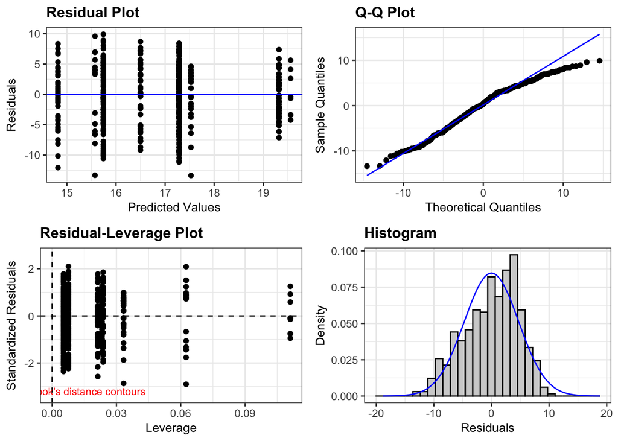

```r
resid_panel(forg_height_lm, plots= c("resid", "qq", "lev", "hist"))
```

#### Performing an ANOVA (Type II tests): F-test results

F values can be found in the table below

```r
Anova(forg_height_lm)
```

```
## Anova Table (Type II tests)
##
## Response: foraging_ht_m
##                      Sum Sq  Df F value    Pr(>F)
## species               334.4   3  4.9528  0.002136 **
## rat_removal           362.5   1 16.1081 6.903e-05 ***
## species:rat_removal    32.1   3  0.4757  0.699318
## Residuals           11208.7 498
## ---
## Signif. codes:  0 '***' 0.001 '**' 0.01 '*' 0.05 '.' 0.1 ' ' 1
```

#### Effects plot

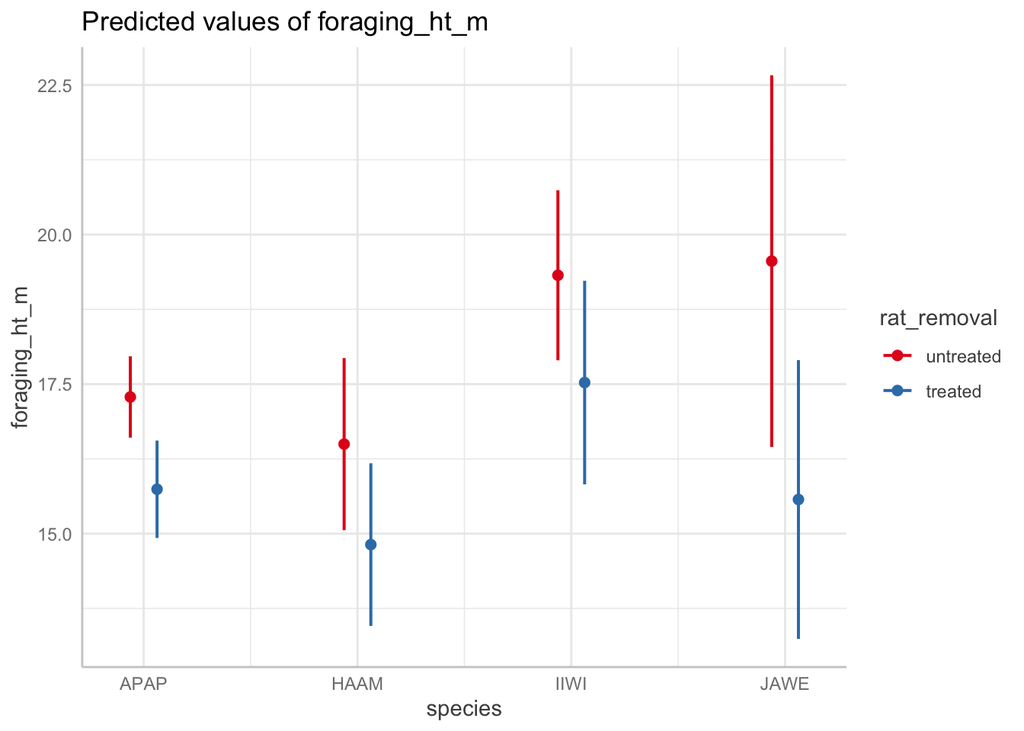

```r
plot(ggeffect(forg_height_lm, terms = c("species", "rat_removal")))
```

## Answer

The magnitude can be better visualized in the following graph.

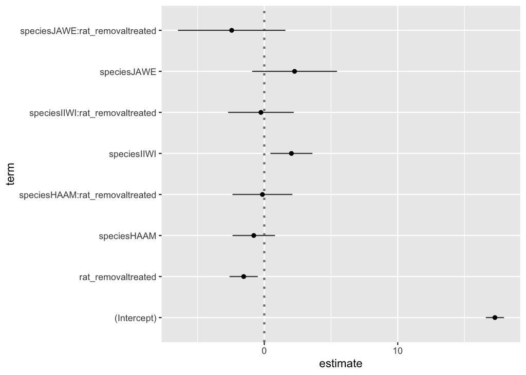

```r
ggcoef(forg_height_lm)
```

## Question 4

- We have not considered the role of kipuka size, or the role of food availability (which is influenced in part by kipuka size).
- Make a new model that adds kipuka area and arthopod biomass as predictors, and include interactions that test whether the treatment effect depends on these additional predictors.
- Report F-tests and effects plots. How do the results of this model differ from the model in #3? How do you interpret the results at this stage?

### Exploratory scatter plots

#### Non-transformed data

- **Residual-Leverage Plot**: the data seems to be evenly distributed on each side of the horizontal line (vertically) which respects the linearity principle. However, the residual points are not distributed even horizontally. This may indicate that the data is skewed.
- **Residual-Leverage Plot**: The residuals are clustered on the left side of the graph and there are outlier points that are located far from the rest of the cluster. One data point is located poast a Cook’s distance contour line indicating an outlier.
- **Conclusion**: Transforming the data is necessary.

```r
forg_kipuka_arth <- lm(foraging_ht_m ~ area_ha*tot_arth_bm,
                     data = bird)

summary(forg_kipuka_arth)
```

```
##
## Call:
## lm(formula = foraging_ht_m ~ area_ha * tot_arth_bm, data = bird)
##
## Residuals:
##      Min       1Q   Median       3Q      Max
## -13.5847  -2.9346   0.5585   3.3605   8.1668
##
## Coefficients:
##                      Estimate Std. Error t value Pr(>|t|)
## (Intercept)         13.436588   0.310149  43.323  < 2e-16 ***
## area_ha              0.654915   0.045740  14.318  < 2e-16 ***
## tot_arth_bm          0.102229   0.022594   4.525 7.56e-06 ***
## area_ha:tot_arth_bm -0.017312   0.002907  -5.956 4.87e-09 ***
## ---
## Signif. codes:  0 '***' 0.001 '**' 0.01 '*' 0.05 '.' 0.1 ' ' 1
##
## Residual standard error: 4.111 on 502 degrees of freedom
## Multiple R-squared:  0.2912, Adjusted R-squared:  0.287
## F-statistic: 68.76 on 3 and 502 DF,  p-value: < 2.2e-16
```

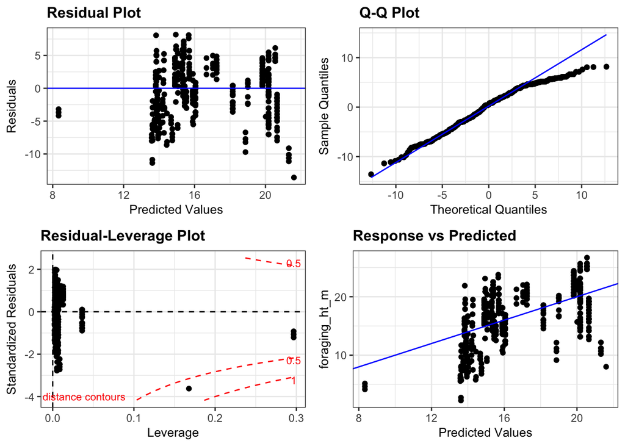

```r
resid_panel(forg_kipuka_arth, plots= c("resid", "qq", "lev", "yvp"))
```

#### Log10-transformed data

Log-transforming the data allowed to even distribute the residual points horizontally on the Residual Plot. In the Residual-Leverage plot, the data is still clustered to the left but less than before and no point is crossing a Cook’s distance contour line.

```r
forg_kipuka_arth <- lm(foraging_ht_m ~ area_ha*log10(tot_arth_bm),
                     data = bird)

summary(forg_kipuka_arth)
```

```
##
## Call:
## lm(formula = foraging_ht_m ~ area_ha * log10(tot_arth_bm), data = bird)
##
## Residuals:
##      Min       1Q   Median       3Q      Max
## -16.8709  -2.8754   0.4851   3.3998   8.7105
##
## Coefficients:
##                            Estimate Std. Error t value Pr(>|t|)
## (Intercept)                13.96039    0.29723  46.969  < 2e-16 ***
## area_ha                     0.45246    0.05898   7.671 8.95e-14 ***
## log10(tot_arth_bm)          0.83487    0.36289   2.301   0.0218 *
## area_ha:log10(tot_arth_bm)  0.02097    0.06456   0.325   0.7455
## ---
## Signif. codes:  0 '***' 0.001 '**' 0.01 '*' 0.05 '.' 0.1 ' ' 1
##
## Residual standard error: 4.212 on 502 degrees of freedom
## Multiple R-squared:  0.256,  Adjusted R-squared:  0.2516
## F-statistic: 57.58 on 3 and 502 DF,  p-value: < 2.2e-16
```

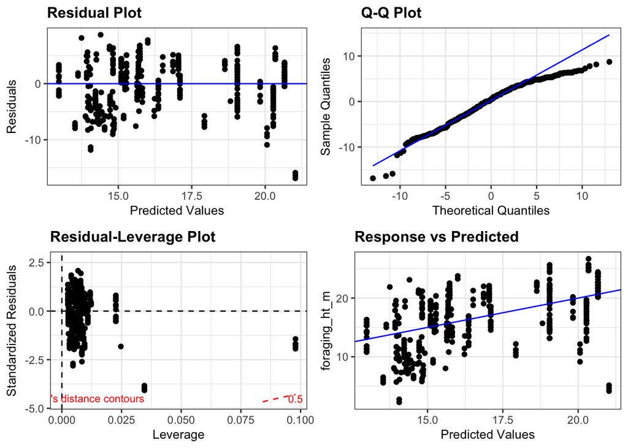

```r
resid_panel(forg_kipuka_arth, plots= c("resid", "qq", "lev", "yvp"))
```

### Setting the new model

```r
forg_4var_lm <- lm(foraging_ht_m ~ species*rat_removal + area_ha*rat_removal + log(tot_arth_bm)*rat_removal, data = bird)

# here, we have 3 predictors: species, treatment (rat_removal), kipuka size (area_ha) and insect biomass (tot_arth_bm).

# we are also looking at the interactions:
## does the treatment affect bird species differently?
## does the treatment affect the the insect biomass?
## does the treatment change with kipuka size ?

summary(forg_4var_lm)
```

```
##
## Call:
## lm(formula = foraging_ht_m ~ species * rat_removal + area_ha *
##     rat_removal + log(tot_arth_bm) * rat_removal, data = bird)
##
## Residuals:
##      Min       1Q   Median       3Q      Max
## -16.9299  -2.6697   0.4865   3.0832   8.2793
##
## Coefficients:
##                                     Estimate Std. Error t value Pr(>|t|)
## (Intercept)                         14.49493    0.42100  34.430  < 2e-16 ***
## speciesHAAM                         -1.92240    0.72077  -2.667  0.00790 **
## speciesIIWI                         -0.71269    0.75522  -0.944  0.34579
## speciesJAWE                          1.00427    1.43311   0.701  0.48378
## rat_removaltreated                  -0.63337    0.64823  -0.977  0.32901
## area_ha                              0.48019    0.06445   7.451 4.17e-13 ***
## log(tot_arth_bm)                     0.43081    0.15294   2.817  0.00504 **
## speciesHAAM:rat_removaltreated       0.90109    1.01149   0.891  0.37344
## speciesIIWI:rat_removaltreated       1.84016    1.14296   1.610  0.10804
## speciesJAWE:rat_removaltreated      -0.99452    1.81140  -0.549  0.58323
## rat_removaltreated:area_ha          -0.07958    0.09735  -0.817  0.41408
## rat_removaltreated:log(tot_arth_bm) -0.05674    0.25669  -0.221  0.82515
## ---
## Signif. codes:  0 '***' 0.001 '**' 0.01 '*' 0.05 '.' 0.1 ' ' 1
##
## Residual standard error: 4.172 on 494 degrees of freedom
## Multiple R-squared:  0.2817, Adjusted R-squared:  0.2657
## F-statistic: 17.61 on 11 and 494 DF,  p-value: < 2.2e-16
```